# GAM N-mixtures

Nicholas Clark

2024-01-24

# Example 1

First we will use a simple simulation with multiple replicates at each timepoint to ensure that we can recover important temporal variation in latent abundance. The simulation produces observations for 6 timepoints with 5 replications per timepoint for 2 species, each with different temporal trends and detection probabilities

```r
library(mvgam)
library(ggplot2)
library(dplyr)
```

```r
set.seed(999)
data.frame(site = 1,
           trend = 1,
           replicate = rep(1:5, 6),
           time = sort(rep(1:6, 5)),
           species = 'sp_1',
           truth = c(rep(28, 5),
                     rep(26, 5),
                     rep(23, 5),
                     rep(16, 5),
                     rep(14, 5),
                     rep(14, 5)),
           obs = c(rbinom(5, 28, 0.7),
                   rbinom(5, 26, 0.7),
                   rbinom(5, 23, 0.7),
                   rbinom(5, 15, 0.7),
                   rbinom(5, 14, 0.7),
                   rbinom(5, 14, 0.7))) %>%
  dplyr::mutate(series = paste0('site_', site,
                                '_', species,
                                '_rep_', replicate),
                time = as.numeric(time),
                cap = 50) %>%
  dplyr::select(- replicate) -> testdat

# Add another species
testdat = testdat %>%
  dplyr::bind_rows(data.frame(site = 1,
                              trend = 2,
                              replicate = rep(1:5, 6),
                              time = sort(rep(1:6, 5)),
                              species = 'sp_2',
                              truth = c(rep(4, 5),
                                        rep(7, 5),
                                        rep(15, 5),
                                        rep(16, 5),
                                        rep(19, 5),
                                        rep(18, 5)),
                              obs = c(rbinom(5, 4, 0.45),
                                      rbinom(5, 7, 0.45),
                                      rbinom(5, 15, 0.45),
                                      rbinom(5, 16, 0.45),
                                      rbinom(5, 19, 0.45),
                                      rbinom(5, 18, 0.45))) %>%
                     dplyr::mutate(series = paste0('site_', site,
                                                   '_', species,
                                                   '_rep_', replicate),
                                   time = as.numeric(time),
                                   cap = 30) %>%
                     dplyr::select(- replicate))
```

Add factor variables for indexing species and series IDs

```r
testdat$species <- as.factor(testdat$species)
testdat$series <- factor(testdat$series,
                         levels = unique(testdat$series))
```

The `trend_map` object operates by species here to state how the replicate observations need to be linked to the latent abundance processes

```r
trend_map <- testdat %>%
  dplyr::select(trend, series) %>%
  dplyr::distinct()
trend_map
```

```
##    trend            series
## 1      1 site_1_sp_1_rep_1
## 2      1 site_1_sp_1_rep_2
## 3      1 site_1_sp_1_rep_3
## 4      1 site_1_sp_1_rep_4
## 5      1 site_1_sp_1_rep_5
## 6      2 site_1_sp_2_rep_1
## 7      2 site_1_sp_2_rep_2
## 8      2 site_1_sp_2_rep_3
## 9      2 site_1_sp_2_rep_4
## 10     2 site_1_sp_2_rep_5
```

Fit a model that allows species to have different detection probabilities and different temporal trends (suppressing the output as the model runs to avoid seeing all the `Cmdstan` messaging)

```r
mod <- mvgam(
  # the observation formula sets up linear predictors for
  # detection probability
  formula = obs ~ species - 1,

  # the trend_formula sets up the linear predictors for
  # the latent abundance processes
  trend_formula = ~ s(time, by = species, k = 4) +
        species,
  trend_map = trend_map,
  family = nmix(),
  data = testdat,
  # priors can be set using {brms} functionality
  priors = c(prior(std_normal(), class = b),
             prior(normal(1, 1.5), class = Intercept_trend)))
```

View the automatically-generated `Stan` code to get a sense of how the marginalization over latent N works

```r
code(mod)
```

```
## // Stan model code generated by package mvgam
## functions {
##   /* Functions to return the log probability of a Poisson Binomial Mixture */
##
##   /* see Bollen et al 2023 for details (https://doi.org/10.1002/ece3.10595)*/
##   real poisbin_lpmf(array[] int count, int k, array[] real lambda,
##                     array[] real p) {
##     if (max(count) > k) {
##       return negative_infinity();
##     }
##     return poisson_log_lpmf(k | lambda) + binomial_logit_lpmf(count | k, p);
##   }
##   vector pb_logp(array[] int count, int max_k, array[] real lambda,
##                  array[] real p) {
##     int c_max = max(count);
##     if (max_k < c_max) {
##       reject("cap variable max_k must be >= observed counts");
##     }
##     vector[max_k + 1] lp;
##     for (k in 0 : (c_max - 1)) {
##       lp[k + 1] = negative_infinity();
##     }
##     for (k in c_max : max_k) {
##       lp[k + 1] = poisbin_lpmf(count | k, lambda, p);
##     }
##     return lp;
##   }
##   real pb_lpmf(array[] int count, array[] int max_k, array[] real lambda,
##                array[] real p) {
##     // Take maximum of all supplied caps, in case they vary for some reason
##     int max_k_max = max(max_k);
##     vector[max_k_max + 1] lp;
##     lp = pb_logp(count, max_k_max, lambda, p);
##     return log_sum_exp(lp);
##   }
##   /* Functions to generate truncated Poisson variates */
##   array[] int nmix_rng(array[] int count, array[] int max_k,
##                        array[] real lambda, array[] real p) {
##     // Take maximum of all supplied caps, in case they vary for some reason
##     int max_k_max = max(max_k);
```

[output cut: 174 more lines]

```
##     for (s in 1 : n_series) {
##       for (i in 1 : n) {
##         // true latent abundance
##         latent_ypred[i, s] = latent_truncpred[ytimes_pred[i, s]];
##
##         // observed abundance
##         ypred[i, s] = binomial_rng(latent_ypred[i, s],
##                                    detprob[ytimes_pred[i, s]]);
##
##         // expected values
##         mus[i, s] = detprob[ytimes[i, s]] * latent_ypred[i, s];
##       }
##     }
##   }
## }
```

Summaries of key parameters

```r
summary(mod)
```

[output not shown]

[output cut: 9 more lines]

```
## s(time):seriestrend2 0.544 0.50   0.092 .
## ---
## Signif. codes:  0 '***' 0.001 '**' 0.01 '*' 0.05 '.' 0.1 ' ' 1
##
## Stan MCMC diagnostics:
## n_eff / iter looks reasonable for all parameters
## Rhat looks reasonable for all parameters
## 0 of 2000 iterations ended with a divergence (0%)
## 0 of 2000 iterations saturated the maximum tree depth of 12 (0%)
## E-FMI indicated no pathological behavior
##
## Samples were drawn using NUTS(diag_e) at Wed Jan 24 10:14:17 PM 2024.
## For each parameter, n_eff is a crude measure of effective sample size,
## and Rhat is the potential scale reduction factor on split MCMC chains
## (at convergence, Rhat = 1)
```

`{loo}` functionality works for all `{mvgam}` models to aid in model comparison / selection

```r
loo(mod)
```

```
##
## Computed from 2000 by 60 log-likelihood matrix
##
##          Estimate  SE
## elpd_loo   -140.1 3.2
## p_loo         4.3 0.6
## looic       280.3 6.3
## ------
## Monte Carlo SE of elpd_loo is 0.1.
##
## All Pareto k estimates are good (k < 0.5).
## See help('pareto-k-diagnostic') for details.
```

Traceplots and all other types of MCMC diagnostics that are supported by `{bayesplot}` can be used to assess model failures or nonidentifiabilities. Here are traces of smoothing parameters

```
## No divergences to plot.
```

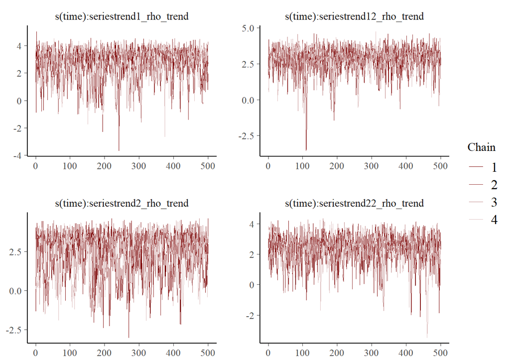

```r
mcmc_plot(mod, type = 'trace')
```

Plot the smooths of time from each species’ latent abundance process (on the log scale)

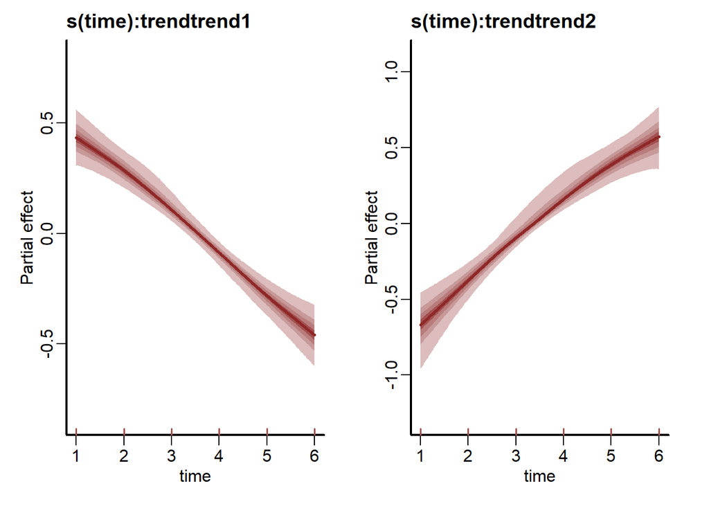

```r
plot(mod, type = 'smooths', trend_effects = TRUE)
```

`{marginaleffects}` support allows for more useful prediction-based interrogations on different scales (i.e. link, response, detection or latent_N). Here are the estimated detection probabilities per species

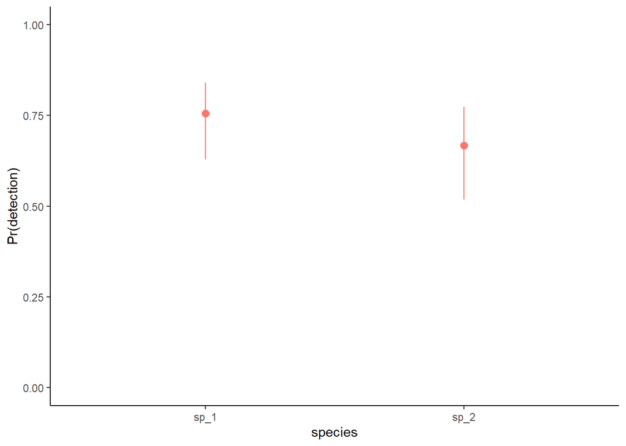

```r
plot_predictions(mod, condition = list('species',
                                       cap = 10),
                 type = 'detection') +
  ylab('Pr(detection)') +
  ylim(c(0, 1)) +
  theme_classic() +
  theme(legend.position = 'none')
```

The model has automatically generated predictions of the latent abundance that are conditional on the observations. We can extract these and produce decent plots using a small function

```r
hc <- hindcast(mod, type = 'latent_N')

plot_latentN = function(hindcasts, data, species = 'sp_1'){
  # Grab the first replicate that represents this series
  series <- as.numeric(unique(data %>%
    dplyr::filter(species == !!species) %>%
    dplyr::pull(series))[1])
  truths <- data %>%
    dplyr::arrange(time, series) %>%
    dplyr::filter(series == !!levels(data$series)[series]) %>%
    dplyr::pull(truth)

  plot(hc,
       ylim = c(max(0, min(truths) - 5), max(truths) + 5),
       ylab = paste0('Latent abundance for ', species),
       series = series)

  points(truths, pch = 16, cex = 0.8, col = 'white')
  points(truths, pch = 16, cex = 0.65)
}
```

Latent abundance plots vs the simulated truths for each species show that low detection probabilities (like for species 2) make it difficult to accurately estimate latent abundance

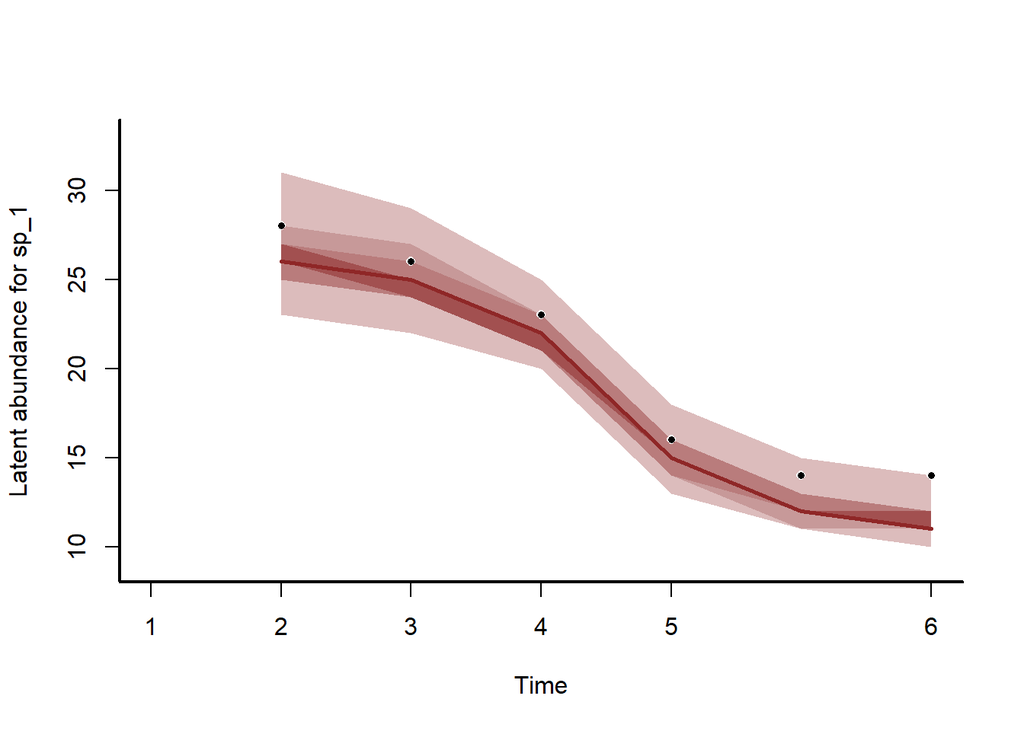

```r
plot_latentN(hc, testdat, species = 'sp_1')
```

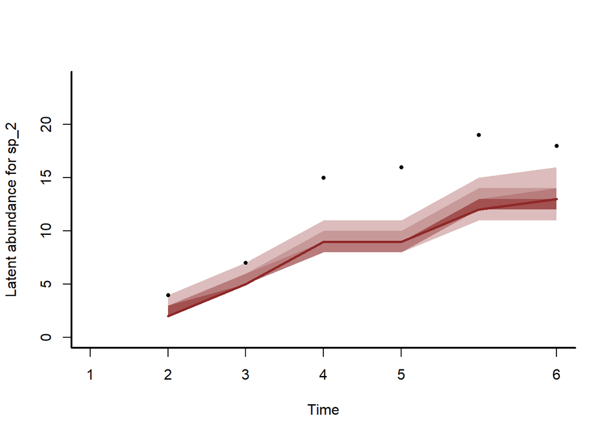

```r
plot_latentN(hc, testdat, species = 'sp_2')
```

# Example 2

Now another example with a larger dataset. We will use data from Jeff Doser’s simulation example from the `{spAbundance}` package: https://www.jeffdoser.com/files/spabundance-web/articles/nmixturemodels. The simulated data include one continuous site-level covariate, one factor site-level covariate and two continuous sample-level covariates.

Download the data and grab observations / covariate measurements for one species. `NA`s allowed in responses but not in covariates

```r
load(url('https://github.com/doserjef/spAbundance/raw/main/data/dataNMixSim.rda'))
data.one.sp <- dataNMixSim
data.one.sp$y <- data.one.sp$y[1, , ]
abund.cov <- dataNMixSim$abund.covs[, 1]
abund.factor <- as.factor(dataNMixSim$abund.covs[, 2])
det.cov <- dataNMixSim$det.covs$det.cov.1[,]
det.cov[is.na(det.cov)] <- rnorm(length(which(is.na(det.cov))))
det.cov2 <- dataNMixSim$det.covs$det.cov.2
det.cov2[is.na(det.cov2)] <- rnorm(length(which(is.na(det.cov2))))
```

Wrangle into the appropriate ‘long’ data format, adding indicators of `time` and `series` for working in `{mvgam}`. We also add a `cap` variable to represent the maximum latent N to marginalize over for each observation

```r
mod_data <- do.call(rbind,
                    lapply(1:NROW(data.one.sp$y), function(x){
                      data.frame(y = data.one.sp$y[x,],
                                 abund_cov = abund.cov[x],
                                 abund_fac = abund.factor[x],
                                 det_cov = det.cov[x,],
                                 det_cov2 = det.cov2[x,],
                                 time = 1:NCOL(data.one.sp$y),
                                 site = paste0('site', x))
                    })) %>%
  dplyr::mutate(series = as.factor(paste0(site, '_', time)),
                site = factor(site, levels = unique(site))) %>%
  dplyr::mutate(time = 1,
                cap = max(data.one.sp$y, na.rm = TRUE) + 8)
```

Data features (225 sites, three replicates per site, though some observations are missing)

```r
NROW(mod_data)
```

```
## [1] 675
```

```r
dplyr::glimpse(mod_data)
```

```
## Rows: 675
## Columns: 9
## $ y         <int> 1, NA, NA, NA, 2, 2, NA, 1, NA, NA, 0, 1, 0, 0, 0, 0, NA, NA…
## $ abund_cov <dbl> -0.3734384, -0.3734384, -0.3734384, 0.7064305, 0.7064305, 0.…
## $ abund_fac <fct> 3, 3, 3, 4, 4, 4, 9, 9, 9, 2, 2, 2, 3, 3, 3, 2, 2, 2, 1, 1, …
## $ det_cov   <dbl> -1.2827999, 0.8834433, -0.4184970, -1.8559529, 0.1954809, 0.…
## $ det_cov2  <dbl> 2.03047314, 1.29603720, -0.02725027, -0.93561380, 1.04555361…
## $ time      <dbl> 1, 1, 1, 1, 1, 1, 1, 1, 1, 1, 1, 1, 1, 1, 1, 1, 1, 1, 1, 1, …
## $ site      <fct> site1, site1, site1, site2, site2, site2, site3, site3, site…
## $ series    <fct> site1_1, site1_2, site1_3, site2_1, site2_2, site2_3, site3_…
## $ cap       <dbl> 21, 21, 21, 21, 21, 21, 21, 21, 21, 21, 21, 21, 21, 21, 21, …
```

```r
head(mod_data)
```

```
##    y  abund_cov abund_fac    det_cov    det_cov2 time  site  series cap
## 1  1 -0.3734384         3 -1.2827999  2.03047314    1 site1 site1_1  21
## 2 NA -0.3734384         3  0.8834433  1.29603720    1 site1 site1_2  21
## 3 NA -0.3734384         3 -0.4184970 -0.02725027    1 site1 site1_3  21
## 4 NA  0.7064305         4 -1.8559529 -0.93561380    1 site2 site2_1  21
## 5  2  0.7064305         4  0.1954809  1.04555361    1 site2 site2_2  21
## 6  2  0.7064305         4  0.9673034  1.91971178    1 site2 site2_3  21
```

The final step for data preparation is the `trend_map`, which sets up the mapping between observation replicates and the latent abundance models. Each site * species combination evolves as a latent ‘factor’, and the observation replicates can share these latent factors appropriately

```r
trend_map <- mod_data %>%
  dplyr::mutate(trend = as.numeric(site)) %>%
  dplyr::select(series, trend)
dplyr::glimpse(trend_map)
```

```
## Rows: 675
## Columns: 2
## $ series <fct> site1_1, site1_2, site1_3, site2_1, site2_2, site2_3, site3_1, …
## $ trend  <dbl> 1, 1, 1, 2, 2, 2, 3, 3, 3, 4, 4, 4, 5, 5, 5, 6, 6, 6, 7, 7, 7, …
```

```r
head(trend_map)
```

```
##    series trend
## 1 site1_1     1
## 2 site1_2     1
## 3 site1_3     1
## 4 site2_1     2
## 5 site2_2     2
## 6 site2_3     2
```

Fit a model using meanfield variational inference. Use penalized splines for each of the covariate effects to detect possible nonlinear associations. These linear predictors can easily handle multidimensional penalized smooths, time-varying or spatially-varying effects, Gaussian Process effects, random slopes and intercepts, or monotonic smooths. I’m purposely not suppressing the model output here so we can see how long it takes to fit

```r
mod <- mvgam(
  # effects of covariates on detection probability;
  # here we use penalized splines for both
  formula = y ~ s(det_cov, k = 4) + s(det_cov2, k = 4),
  # effects of the covariates on latent abundance;
  # here we use a penalized spline for the continuous and
  # hierarchical intercepts for the factor
  trend_formula = ~ s(abund_cov, k = 4) +
    s(abund_fac, bs = 're'),
  # linking multiple observations to each site
  trend_map = trend_map,
  family = nmix(),
  trend_model = 'None',
  data = mod_data,
  # standard normal priors on key regression params
  priors = c(prior(std_normal(), class = 'b'),
             prior(std_normal(), class = 'Intercept'),
             prior(std_normal(), class = 'Intercept_trend')),
  algorithm = 'meanfield',
  samples = 1000)
```

```
## Using cmdstanr as the backend
```

[output not shown]

[output not shown]

```
## ------------------------------------------------------------
## EXPERIMENTAL ALGORITHM:
##   This procedure has not been thoroughly tested and may be unstable
##   or buggy. The interface is subject to change.
## ------------------------------------------------------------
## Gradient evaluation took 0.008214 seconds
## 1000 transitions using 10 leapfrog steps per transition would take 82.14 seconds.
## Adjust your expectations accordingly!
## Begin eta adaptation.
## Iteration:   1 / 250 [  0%]  (Adaptation)
## Iteration:  50 / 250 [ 20%]  (Adaptation)
## Iteration: 100 / 250 [ 40%]  (Adaptation)
## Iteration: 150 / 250 [ 60%]  (Adaptation)
## Iteration: 200 / 250 [ 80%]  (Adaptation)
## Success! Found best value [eta = 1] earlier than expected.
## Begin stochastic gradient ascent.
##   iter             ELBO   delta_ELBO_mean   delta_ELBO_med   notes
##    100        -1176.260             1.000            1.000
##    200         -721.663             0.815            1.000
##    300         -696.784             0.555            0.630
##    400         -693.322             0.418            0.630
##    500         -693.759             0.334            0.036
##    600         -692.210             0.279            0.036
##    700         -689.148             0.240            0.005   MEDIAN ELBO CONVERGED
## Drawing a sample of size 1000 from the approximate posterior...
## COMPLETED.
## Finished in  82.0 seconds.
```

Inspect the model summary but don’t bother looking at estimates for all individual spline coefficients

```r
summary(mod, include_betas = FALSE)
```

```
## GAM observation formula:
## y ~ s(det_cov, k = 4) + s(det_cov2, k = 4)
##
## GAM process formula:
## ~s(abund_cov, k = 4) + s(abund_fac, bs = "re")
##
## Family:
## nmix
##
## Link function:
## log
##
## Trend model:
## None
##
## N process models:
## 225
##
## N series:
## 675
##
## N timepoints:
## 1
##
## Status:
## Fitted using Stan
## 1 chains, each with iter = 1000; warmup = ; thin = 1
## Total post-warmup draws = 1000
##
##
## GAM observation model coefficient (beta) estimates:
##             2.5%  50% 97.5% Rhat n.eff
## (Intercept)  0.4 0.67  0.94  NaN   NaN
##
## Approximate significance of GAM observation smooths:
##             edf Chi.sq p-value
## s(det_cov)  NaN   88.6 0.00036 ***
## s(det_cov2) NaN  283.1 7.2e-07 ***
## ---
## Signif. codes:  0 '***' 0.001 '**' 0.01 '*' 0.05 '.' 0.1 ' ' 1
##
## GAM process model coefficient (beta) estimates:
##                    2.5%   50% 97.5% Rhat n.eff
## (Intercept)_trend -0.76 -0.65 -0.55  NaN   NaN
##
## GAM process model group-level estimates:
##                           2.5%  50% 97.5% Rhat n.eff
## mean(s(abund_fac))_trend 0.310 0.43  0.54  NaN   NaN
## sd(s(abund_fac))_trend   0.095 0.17  0.29  NaN   NaN
##
## Approximate significance of GAM process smooths:
##               edf     F p-value
## s(abund_cov) 2.03 13.28    0.37
## s(abund_fac) 9.49  0.29    0.50
##
## Posterior approximation used: no diagnostics to compute
```

Use `{marginaleffects}` support for interrogating the model with more targeted predictions. First, inspect the estimated average detection probability

```r
avg_predictions(mod, type = 'detection')
```

```
##
##  Estimate 2.5 % 97.5 %
##     0.633 0.577  0.687
##
## Columns: estimate, conf.low, conf.high
## Type:  detection
```

Next investigate estimated effects of covariates on latent abundance

```r
abund_plots <- plot(conditional_effects(mod,
                                        type = 'link',
                                        effects = c('abund_cov',
                                                    'abund_fac')),
                    plot = FALSE)
```

The effect of the continuous covariate on expected latent abundance

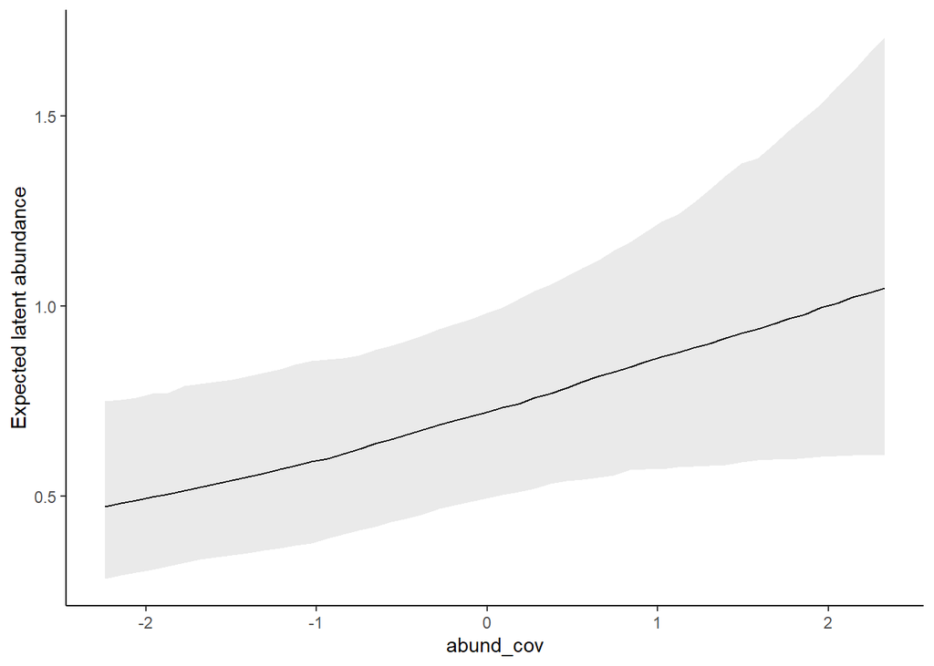

```r
abund_plots[[1]] +
  ylab('Expected latent abundance')
```

The effect of the factor covariate on expected latent abundance, estimated as a hierarchical random effect

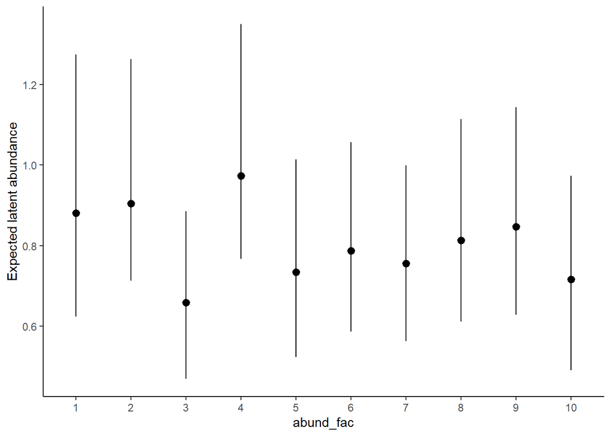

```r
abund_plots[[2]] +
  ylab('Expected latent abundance')
```

Investigate estimated effects of covariates on detection probability

```r
det_plots <- plot(conditional_effects(mod,
                                      type = 'detection',
                                      effects = c('det_cov',
                                                  'det_cov2')),
                  plot = FALSE)
```

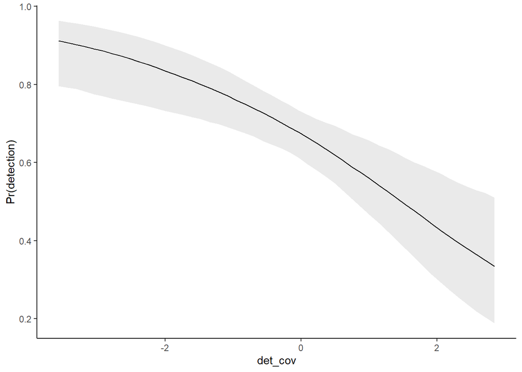

```r
det_plots[[1]] +
  ylab('Pr(detection)')
```

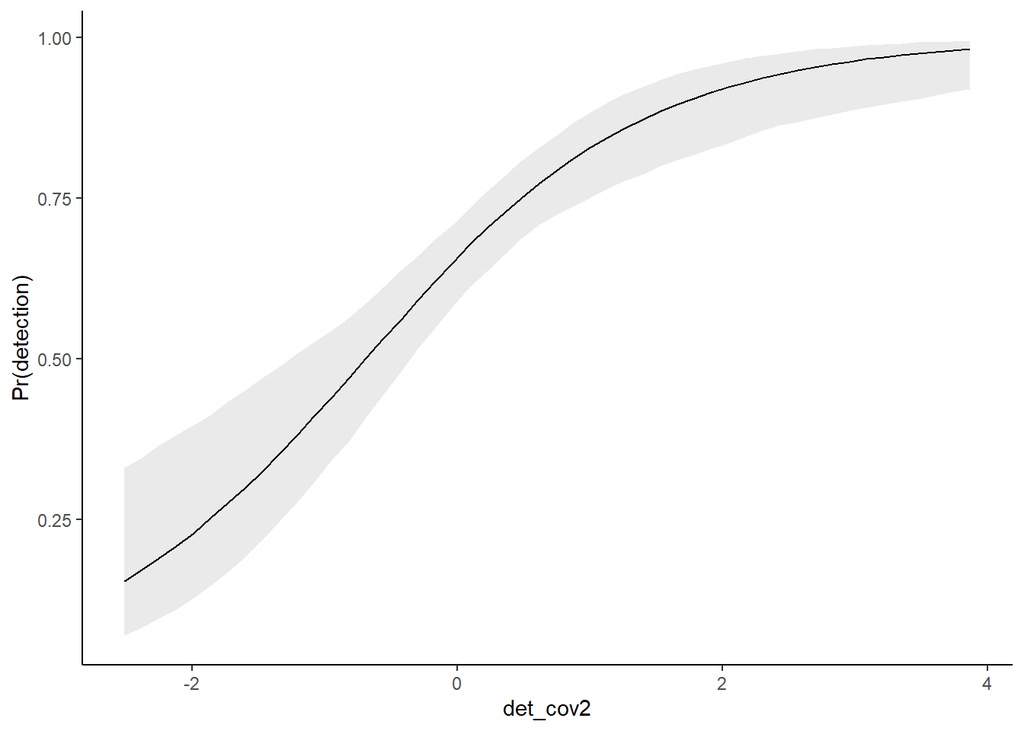

```r
det_plots[[2]] +
  ylab('Pr(detection)')
```

More targeted predictions are also easy with `{marginaleffects}` support: How does detection probability change as we change both detection covariates?

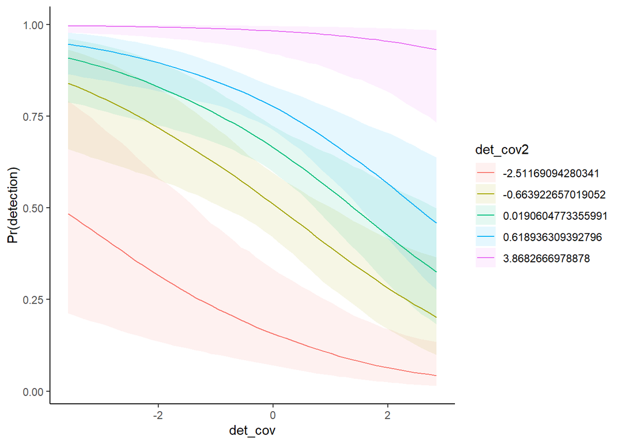

```r
plot_predictions(mod, type = 'detection',
                 condition = c('det_cov',
                               'det_cov2')) +
  theme_classic() +
  ylab('Pr(detection)')
```